# Intro to Clustering and K-Means

Week 7 | Lesson 1.1

[figure not shown]

### LEARNING OBJECTIVES

*After this lesson, you will be able to:*

- Understand basic unsupervised clustering problems
- Format and preprocess data for cluster
- Perform a K-Means Clustering Analysis
- Evaluate clusters for fit

### STUDENT PRE-WORK

*Before this lesson, you should already be able to:*

- Write basic Python including functions
- Have a working knowledge of Pandas and Scikit-Learn

### LESSON GUIDE

| TIMING | TYPE | TOPIC |
| --- | --- | --- |
| 5 min | Opening | Topic description |
| 10 min | Introduction | What is Clustering? |
| 15 min | Demo | Example of Clustering |
| 25 min | Guided Practice | Format your data for clustering |
| 25 min | Independent Practice | Perform a k-means cluster analysis |
| 5 min | Conclusion | Conclusion |

## How robust do you think "unsupervized" classification can be?

- What's you're initial impression?

### Unsupervised Learning

[figure not shown]

Until now, we haven't talked much about unsupervised learning. We use unsupervised methods when we don't have labeled data.

| Pros | Cons |
| --- | --- |
| No labels | Difficult to assess without SME |
| Few or no assumptions about data | Scaling / normalization often necessary |
| Useful for subset / segmentation discovery | Difficult to visualize |
| Great for broad insights | Extremely difficult to tune |
| Many models avalable | No obvious choice in many cases |
| Black magic | Considered "unconventional" for serious problems |

## Introduction: Intro to Clustering (5 mins)

Clustering as a wide variety of applications including:

### Genetics

[figure not shown]

## Consumer Internet

## Business

|  | Identifying Demographics Spending Patterns Consumer Trends Customer Characteristics Recommender Systems Taxonomy / Categorization |
| --- | --- |

## What is meant by "labeled data"?

- Give me some examples!

[figure not shown]

## What problems do you think are implied by "clustering"?

Follow up:

- How accurate do you think these are?
- What kind of data are we talking about?

#### What is Clustering?

[figure not shown]

Clustering is one of the most ubiquitous and widespread methods for understanding a dataset. In clustering, we group points in a dataset together so that the members of that group are more similar to each other than they are to members of other groups. In this sense, we're creating groups to understand our data.

- No "true" target / response to compare
- We apply structure to data, rather than assume some structure (ie: no true value / class / label)
- Predictions based on observed characteristics within data

For instance; Your employer gives you a dataset of voter preferences from a local poll and they want you to figure out just exactly how these voters are grouping based on their preferences. The answer: clustering!

## How is Clustering Different from Classification?

You may be thinking: How is clustering different from classification? If we're just creating groups, aren't the two one and the same? There exists an important distinction between classification and clustering: In classification, we are grouping data according to a set of predefined groups; We know what the characteristics of a mammal are, and humans have the characteristics of that predefined group. In clustering, however, we set out to figure out *if* the points in our dataset have relationships with each other, and we group those with similar characteristics in a cluster. In other words, we need to discover the classes themselves.

## KNN Review

KNN is a supervised classification method, with some important differences. We will review.

[figure not shown]

## How Does Clustering Work? - Demo (10 mins)

The are numerous algorithms for clustering a dataset:

- **K-Means** (mean centroids)
- **Heirarchical** (nested clusters by merging or splitting successively)
- **DBSCAN** (density based)
- Affinity Propagation (graph based approach to let points 'vote' on their preferred 'exemplar')
- Mean Shift (can find number of clusters)
- Spectral Clustering
- Agglomerative Clustering (suite of algorithms all based on applying the same criteria/characteristics of one cluster to others)

Today we're going to look at one of the most commonly used algorithms: k-means.

## K-Means Clustering

### K-Means is the most popular clustering algorithm

It's one of the easier methods to understand and other clustering techniques will be based on some of the assumptions that K-Means is based on.

- # $K = Clusters$
- # $Means = Mean\ of\ cluster\ points$

K-Means is a clustering algorithm that assumes *k* clusters, and then computes these clusters based on the attributes of the available data. The algorithm takes your entire dataset, let's call it *df*, and iterates over its attributes to determine clusters based around centers, known as **centroids**. Unlike many statistical methods, there is no finite way to determine what "k" is; for our methods, we're going to approximate *k* based on distribution of our data.

## Euclidean Refresher

*We are going to leave this here for those of us who want a refresher, and move on...*

[figure not shown]

## K-Means Step by Step

|  | **Step 1.** We have data in a N-Dimensional feature space (2D for example). |
| --- | --- |

|  | **Step 2.** Intialize K centroid (2 here). |
| --- | --- |

|  | **Step 3.** Assign points to *closest* cluster based on _euclidean distance_. $\sqrt{(x_1-x_2)^2 + (y_1-y_2)^2}$ |
| --- | --- |

|  | **Step 4.** Calculate mean of points assigned to centroid (2 here). Update new centroid positions to mean (ie: geometric center). $new\ centroid\ position= \bar{x}, \bar{y}$ |
| --- | --- |

|  | **Step 5.** Repeat step 3-4, updating class membership based on centroid distance. |
| --- | --- |

|  | **Fin.** Convergence is met once all points no longer change to a new class (defined by closest centroid distance). |
| --- | --- |

## Another Example

[figure not shown]

## A few K-Means caveats...

Nothing's perfect.

## K-Means is sensitive to outliers

[figure not shown]

# K-Means is also sensitive to centroid initialization

[figure not shown]

## (2 mins) How Many K?

Sometimes it's obvious, and sometimes it's not! What do you think?

| 1 | 2 | 3 |
| --- | --- | --- |

# Chosing K

You may want to select an appropriate method of initializing your centroids, for instance:

- Randomly
- Manually
- Special KMeans++ method in Sklearn (*This initializes the centroids to be generally distant from each other*)

**Depending on your problem, you may find some of these are better than others.**

*Manual is recommended if you know your data well enough to see the clusters without much help.*

## A note about K-Means convergence

In general, k-means will converge to a solution and return a partition of k clusters, even if no natural clusters exist in the data. It's entirely possible the clusters may not mean anything at all. **Knowing your domain and dataset is essential.**

[figure not shown]

### K-Means in sklearn

Implementing K-Means with sklearn, follows a familiar pattern:

```python
%matplotlib inline

from sklearn.cluster import KMeans
from sklearn.metrics import silhouette_score
import numpy as np
import seaborn as sns
import matplotlib.pyplot as plt
import matplotlib
import pandas as pd
matplotlib.style.use('ggplot')

test_data = [
    (1, 2), (3, 5), (6, 5), (2, 1)
]

df = pd.DataFrame(test_data, columns=['x', 'y'])
df
```

|  | x | y |
| --- | --- | --- |
| 0 | 1 | 2 |
| 1 | 3 | 5 |
| 2 | 6 | 5 |
| 3 | 2 | 1 |

```python
k = 3
model = KMeans(n_clusters = k)
model.fit(df)
```

```
KMeans(copy_x=True, init='k-means++', max_iter=300, n_clusters=3, n_init=10,
    n_jobs=1, precompute_distances='auto', random_state=None, tol=0.0001,
    verbose=0)
```

After we fit our data, we have our predicted labels available from `model.labels_`, and `model.cluster_centers_`.

```python
labels = model.labels_
centroids = model.cluster_centers_

print labels, centroids
```

```
[0 2 1 0] [[ 1.5  1.5]
 [ 6.   5. ]
 [ 3.   5. ]]
```

We can also test the *fit* of our centroids and clusters by computing the **Silhouette Coefficient**, a metric to test the cohesion of local points to their clusters and the seperation to other clusters.

**We will talk about the Silhouette Coefficient in more depth in our next lesson**

```python
score = silhouette_score(df, labels, metric='euclidean')
score
```

[output not shown]

## sklearn + K-Means with "Isotopic Composition Plutonium Batches"

We have a nice [data dictionary](https://vincentarelbundock.github.io/Rdatasets/doc/cluster/pluton.html)

```python
csv_file = "https://vincentarelbundock.github.io/Rdatasets/csv/cluster/pluton.csv"

df = pd.read_csv(csv_file)
df.head(5)
```

|  | Unnamed: 0 | Pu238 | Pu239 | Pu240 | Pu241 |
| --- | --- | --- | --- | --- | --- |
| 0 | 1 | 0.126 | 75.804 | 21.204 | 2.180 |
| 1 | 2 | 0.133 | 75.515 | 21.408 | 2.240 |
| 2 | 3 | 0.127 | 75.175 | 21.668 | 2.305 |
| 3 | 4 | 0.156 | 78.872 | 18.428 | 1.906 |
| 4 | 5 | 0.503 | 73.317 | 20.223 | 4.128 |

## Let's use Pu239 and Pu240 as our X and Y

1. We select only columns "Pu239" and "Pu240" to use for our example
2. Plot it to see how it looks
3. Initialize an instance of `KMeans` from `sklearn`
4. Fit our sliced dataframe with the `fit`

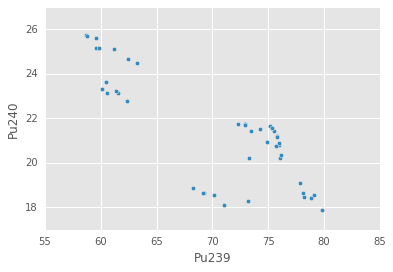

```python
# Slice and check out our plot
features = ['Pu239', 'Pu240']
df[features].plot(kind="scatter", x=features[0], y=features[1])
```

```
Silhouette Score:  -0.00641212398399
```

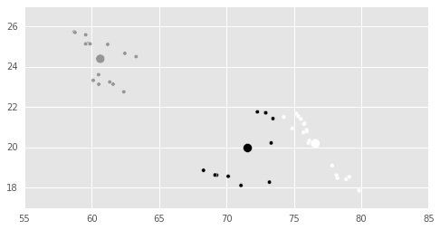

```python
# Run K-Means against our 2 features
k = 3
model = KMeans(n_clusters = k)
model.fit(df[features].values)

# Check our results
# Assign clusters back to our dataframe
df['cluster'] = model.labels_

# Get our centrois
centroids = model.cluster_centers_
cc = pd.DataFrame(centroids)

# Setup some sweet colors for plotting (for later)
# colors = {'D':'red', 'E':'blue', 'F':'green'}

# update x,y of our final clusters to plot later
fig, ax = plt.subplots(figsize=(8,4))

# Plot the scatter of our points with calculated centroids
ax.scatter(df[features[0]], df[features[1]], c=df['cluster'])
ax.scatter(cc[0], cc[1], c=cc.index, s=100)

# And our score
print "Silhouette Score: ", silhouette_score(df, df['cluster'], metric='euclidean')
```

# Scale this data using standard scaler

```
Silhouette Score:  -0.00759844622131
```

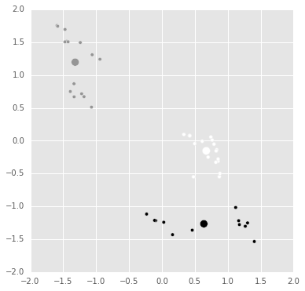

```python
from sklearn.preprocessing import scale

df = pd.read_csv(csv_file)
df[features] = scale(df[features])

model = KMeans(n_clusters = k)
model.fit(df[features])

# Check our results
# Assign clusters back to our dataframe
df['cluster'] = model.labels_

# Get our centrois
centroids = model.cluster_centers_
cc = pd.DataFrame(centroids)

# Setup some sweet colors for plotting (for later)
# colors = {'D':'red', 'E':'blue', 'F':'green'}

# update x,y of our final clusters to plot later
fig, ax = plt.subplots(figsize=(6,6))

# Plot the scatter of our points with calculated centroids
ax.scatter(df[features[0]], df[features[1]], c=df['cluster'])
ax.scatter(cc[0], cc[1], c=cc.index, s=100)

# And our score
print "Silhouette Score: ", silhouette_score(df, df['cluster'], metric='euclidean')
```

# What do we notice?

## (~20 mins) Independent Practice + Lab

Experiment with other features in the plutonium dataset

- Try plotting 2 other features
- Fit a K-Means cluster
  - Without scaling
  - With scaling
- How has your silhouette score differed?

```python
# Let's setup our data again
features = ['Pu239', 'Pu240']

df = pd.read_csv(csv_file)
df[features].head(5)

# Complete your analysis here
```

|  | Pu239 | Pu240 |
| --- | --- | --- |
| 0 | 75.804 | 21.204 |
| 1 | 75.515 | 21.408 |
| 2 | 75.175 | 21.668 |
| 3 | 78.872 | 18.428 |
| 4 | 73.317 | 20.223 |

## K-Means Tradeoffs

| Strengths | Weaknesses |
| --- | --- |
| K-Means is popular because it's simple and computationally efficient. | However, K-Means is highly scale dependent and isn't suitable for data of varying shapes and densities. |
| Easy to see results / intuitive. | Evaluating results is more subjective, requiring much more human evaluation than trusted metrics. |

## (2 mins) How is clustering different than classification?

# Closing

- Unsupervised Clustering Model
- Similar to KNN (but is “clustering”)
- Iteratively Finds Labels Given K
- Easy to implement in sklearn
- Sensitive to shape, scale of data
- Optimal K hard to evaluate

## Lab: Perform a K-Means Analysis

Now that we've walked through the process of clustering, it's time to try it on your own. We're going to be working with the mtcars data set, and your job is to cluster these cars to understand their various attributes.

The dataset contains a listing of 33 different cars from a used car dealership - your task is the cluster the cars to discover their groupings. For each car, you have a variety of technical information related to the car's performance.

Open the data and starter code and try to work through both exercises with a partner. Do your best!

**Check:** Were you able to complete the starter code? Discuss the two variables you chose and explain how your plots demonstrate the data.

## Bonus Activity

Perform a K-Means Analysis on this dataset: https://vincentarelbundock.github.io/Rdatasets/csv/ggplot2/diamonds.csv

### Bonus BONUS Activity

While it's not always a great idea, but can you research and implement a 3D scatterplot of the above data in this notebook?

```python
df = pd.read_csv("https://vincentarelbundock.github.io/Rdatasets/csv/ggplot2/diamonds.csv")
df.head()
```

|  | Unnamed: 0 | carat | cut | color | clarity | depth | table | price | x | y | z |
| --- | --- | --- | --- | --- | --- | --- | --- | --- | --- | --- | --- |
| 0 | 1 | 0.23 | Ideal | E | SI2 | 61.5 | 55 | 326 | 3.95 | 3.98 | 2.43 |
| 1 | 2 | 0.21 | Premium | E | SI1 | 59.8 | 61 | 326 | 3.89 | 3.84 | 2.31 |
| 2 | 3 | 0.23 | Good | E | VS1 | 56.9 | 65 | 327 | 4.05 | 4.07 | 2.31 |
| 3 | 4 | 0.29 | Premium | I | VS2 | 62.4 | 58 | 334 | 4.20 | 4.23 | 2.63 |
| 4 | 5 | 0.31 | Good | J | SI2 | 63.3 | 58 | 335 | 4.34 | 4.35 | 2.75 |